# DS 3001 Text Mining Lab

Group 10

3/24/2021

# Problem Statement

The purpose of this lab was to track the level of support nationally and regionally for the field of Data Science. The goal was to get a general idea of patterns associated with articles being written on the broad topic of data science. To do this, our team explored periodicals from around the country to track relative positive or negative sentiments and word frequencies. We used the library search engine NexusUni to find newspapers from different regions of the U.S. We also divided up the country into 3 main regions for analysis - the east coast, west coast, and midwest. From each region, two main newspapers were selected with no more than 100 articles each on the topic of data science.

# Newspapers Selected

## Eastern Newspapers

Pittsburgh Gazette - Pennsylvania

New York Times - New York

## Midwestern Newspapers

The Telegraph Herald - Iowa

The Daily Oklahoman - Oklahoma

## Western Newspapers

The LA Times - California

Spokesman Review - Washington

# Import the data

```r
midwest_file_1 = "mid_west_file_1_1.rtf"
midwest_file_2 = "mid_west_file_2_1.rtf"
east_file_1 = "NYFiles.RTF"
east_file_2 = "PhillyFiles.RTF"
west_file_1 = "California_LATimes_docs.RTF"
west_file_2 = "Washington_docs.RTF"
```

## Process and clean data for text analysis

```r
# function to clean and process the rtf files
process_rtf = function(file_name){

  rtf_result = read_lines(file_name)

  rtf_tibble = tibble(rtf_result) %>%
    mutate(rtf_result = as.character(rtf_result))

  # remove all the info contained in {} and some giberish
  rtf_tibble <- rtf_tibble %>%
    unnest_tokens(word, rtf_result)

  # remove unimportant words
  rtf_tibble = rtf_tibble %>%
    anti_join(stop_words)

  # find the count of each word
  rtf_tibble = rtf_tibble %>%
    count(word, sort = TRUE)
  # remove rows with numbers on it
  rtf_tibble <- rtf_tibble %>%
    filter(!grepl("[[:digit:]]", word))
  # remove na
  rtf_tibble <- rtf_tibble %>%
    filter(!str_detect(word, "na"))

  return(rtf_tibble)

}
```

```r
midwest_1 = process_rtf(midwest_file_1)
midwest_2 = process_rtf(midwest_file_2)
east_1 = process_rtf(east_file_1)
east_2 = process_rtf(east_file_2)
west_1 = process_rtf(west_file_1)
west_2 = process_rtf(west_file_2)
```

## Combine newspapers into regions

```r
combined_newspapers_into_regions = function(paper1, paper2){
  temp = rbind(paper1, paper2) %>%
  group_by(word) %>%
  summarize(n=sum(n)) %>%
  arrange(-n)

  return(temp)
}
```

```r
midwest = combined_newspapers_into_regions(midwest_1, midwest_2)
east = combined_newspapers_into_regions(east_1, east_2)
west = combined_newspapers_into_regions(west_1, west_2)
```

# Sentiment analysis

```r
# load sentiment data
get_sentiments('afinn')
```

```
## # A tibble: 2,477 x 2
##    word       value
##    <chr>      <dbl>
##  1 abandon       -2
##  2 abandoned     -2
##  3 abandons      -2
##  4 abducted      -2
##  5 abduction     -2
##  6 abductions    -2
##  7 abhor         -3
##  8 abhorred      -3
##  9 abhorrent     -3
## 10 abhors        -3
## # … with 2,467 more rows
```

```r
get_sentiments('nrc')
```

```
## # A tibble: 13,901 x 2
##    word        sentiment
##    <chr>       <chr>
##  1 abacus      trust
##  2 abandon     fear
##  3 abandon     negative
##  4 abandon     sadness
##  5 abandoned   anger
##  6 abandoned   fear
##  7 abandoned   negative
##  8 abandoned   sadness
##  9 abandonment anger
## 10 abandonment fear
## # … with 13,891 more rows
```

```r
get_sentiments('bing')
```

```
## # A tibble: 6,786 x 2
##    word        sentiment
##    <chr>       <chr>
##  1 2-faces     negative
##  2 abnormal    negative
##  3 abolish     negative
##  4 abominable  negative
##  5 abominably  negative
##  6 abominate   negative
##  7 abomination negative
##  8 abort       negative
##  9 aborted     negative
## 10 aborts      negative
## # … with 6,776 more rows
```

## Create sentiment analysis for each region

```r
sentiment = function(raw){

  afinn = raw %>%
    inner_join(get_sentiments("afinn"))

  nrc = raw %>%
    inner_join(get_sentiments("nrc"))

  bing = raw %>%
    inner_join(get_sentiments("bing"))

  return(list("afinn" = afinn, "nrc" = nrc, "bing" = bing))
}
```

```r
midwest_sent = sentiment(midwest)
midwest_afinn = midwest_sent$afinn
midwest_nrc = midwest_sent$nrc
midwest_bing = midwest_sent$bing

east_sent = sentiment(east)
east_afinn = east_sent$afinn
east_nrc = east_sent$nrc
east_bing = east_sent$bing

west_sent = sentiment(west)
west_afinn = west_sent$afinn
west_nrc = west_sent$nrc
west_bing = west_sent$bing
```

# Plots

```r
# a function that takes in afinn data and readies it for the creation of a histogram (fancy bar plot)
afinn_to_histogram_data = function(afinn_data){
  temp = afinn_data %>%
    group_by(value)%>%
    summarize(n=n())

  return(temp)
}

# create the afinn plot we desire
afinn_plot = function(afinn_data){
  plt = afinn_data %>%
    ggplot(
      aes(
        x=value,
        y=n,
        fill=n
      )
    )+
    geom_bar(
      stat='identity'
    )+
    geom_smooth(
      method='loess',
      se=F,
      formula='y~x'
    ) +
    scale_x_continuous(
    breaks = seq(-5, 6, by = 1),
    limits = c(-5, 6)
  )

  return(plt)
}
```

## Histogram

### Combine regional data for histogram

```r
# prep the data for the histogram
midwest_afinn_hist_data = midwest_afinn %>%
  afinn_to_histogram_data() %>%
  mutate(region = 'midwest')

east_afinn_hist_data = east_afinn %>%
  afinn_to_histogram_data() %>%
  mutate(region = 'east')

west_afinn_hist_data = west_afinn %>%
  afinn_to_histogram_data() %>%
  mutate(region = 'west')

all_regions_afinn_hist_data = rbind(midwest_afinn_hist_data, east_afinn_hist_data, west_afinn_hist_data)
```

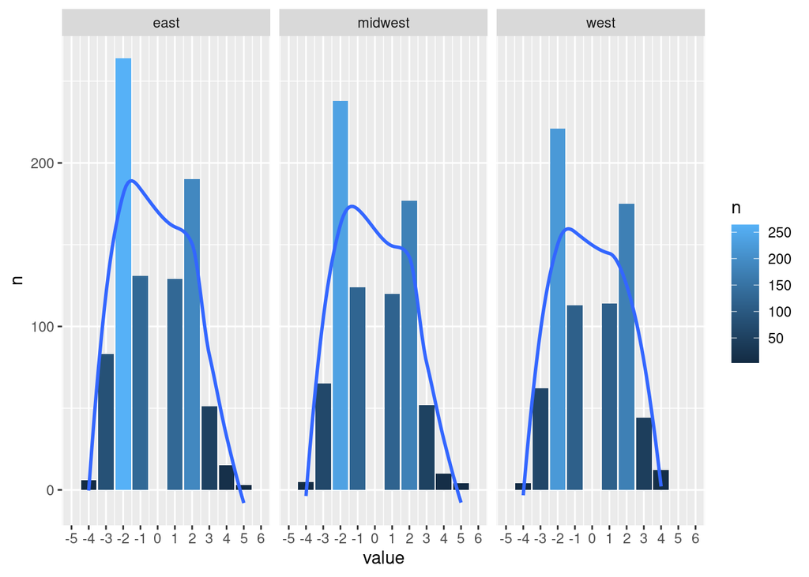

```r
all_regions_afinn_hist_data %>%
  afinn_plot() +
  facet_wrap(
    .~region
  )
```

## Cloud Plot

```r
afinn_cloud_plot = function(afinn_data){
  plt = afinn_data %>%
  ggplot(
    aes(
      label=word,
      size=n
    )
  )+
  geom_text_wordcloud(
  )+
  theme_minimal()

  return(plt)
}
```

### Combine data for cloud plot

```r
midwest_afinntop50 <- midwest_afinn %>%
  mutate(region = 'midwest')
midwest_afinntop50 <- head(arrange(midwest_afinntop50, desc(n)), 50)

east_afinntop50 <- east_afinn %>%
  mutate(region = 'east')
east_afinntop50 <-  head(arrange(east_afinntop50, desc(n)), 50)

west_afinntop50 <- west_afinn %>%
  mutate(region = 'west')
west_afinntop50 <- head(arrange(west_afinntop50, desc(n)), 50)

all_regions_afinn = rbind(midwest_afinntop50, east_afinntop50, west_afinntop50)
```

```r
all_regions_afinn %>%
  afinn_cloud_plot(
  )+
  facet_wrap(
    .~region
  )
```

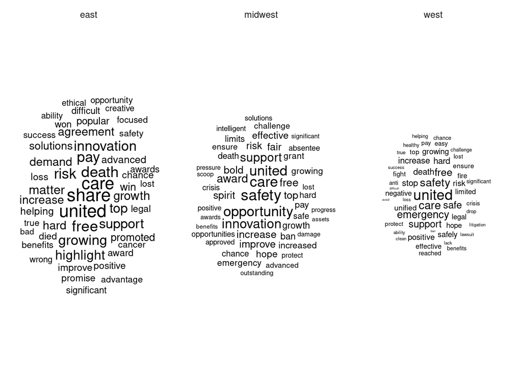

[figure not shown]